# Part 1

Import the required libraries-

```python
import numpy as np
from sklearn.utils import shuffle
from sklearn.preprocessing import MinMaxScaler,OneHotEncoder
from sklearn.model_selection import train_test_split
import tensorflow as tf
from tensorflow import keras
from tensorflow.keras.models import Sequential
from tensorflow.keras.layers import Activation,Dense,Dropout,Flatten
from tensorflow.keras.optimizers import Adam, SGD
from tensorflow.keras.metrics import mean_squared_error
from tensorflow.keras import initializers
from matplotlib import pyplot as plt
from keras.models import Model
from sklearn.manifold import TSNE as tsne
from sklearn.decomposition import PCA as pca
import librosa
import IPython.display as ipd
```

Import the mnist dataset.

```python
mnist = tf.keras.datasets.mnist
data=mnist.load_data()
```

Extract the training and test sets from the dataset.

```python
train_x=data[0][0]
train_y=data[0][1].reshape(-1,1)
test_x=data[1][0]
test_y=data[1][1].reshape(-1,1)
```

Process the datasets - Scale the pixel values to range (0,1), and one-hot encode the labels.

```python
# Process the data

def process_data(x,y):


  # Flatten the data
  samples=[]
  for sample in x[:]:
    samples.append(sample.flatten())

  x=np.array(samples)

  # Encode the labels
  enc=OneHotEncoder()

  enc.fit(y)

  onehotlabels = enc.transform(y).toarray()
  y=onehotlabels

  # Shuffle the data
  x,y=shuffle(x,y)

  # Scale the data
  scaler=MinMaxScaler(feature_range=(0,1))

  x=scaler.fit_transform(x)


  return x,y



train_x,train_y=process_data(train_x,train_y)
test_x,test_y=process_data(test_x,test_y)
```

Configure the GPU.

```python
# Configure GPU

physical_devices=tf.config.experimental.list_physical_devices("GPU")
tf.config.experimental.set_memory_growth(physical_devices[0],True)
```

Build a baseline model with 5 hidden layers- each with 1024 units. Compile and train the model.

```python
baseline_model=Sequential(
    [

    Dense(units=1024,input_shape=(784,),activation='relu',kernel_initializer=initializers.HeNormal),
    Dense(units=1024,activation='relu',kernel_initializer=initializers.HeNormal),
    Dense(units=1024,activation='relu',kernel_initializer=initializers.HeNormal),
    Dense(units=1024,activation='relu',kernel_initializer=initializers.HeNormal),
    Dense(units=1024,activation='relu',kernel_initializer=initializers.HeNormal),

    Dense(units=10,activation='softmax')

    ]
)

baseline_model.compile(optimizer=Adam(),loss='binary_crossentropy',metrics=['accuracy']);
baseline_model_hist=baseline_model.fit(x=train_x,y=train_y,batch_size=1024,epochs=50,shuffle=True,verbose=2,validation_data=(test_x,test_y))
```

```
59/59 - 1s - loss: 0.0684 - accuracy: 0.8686 - val_loss: 0.0229 - val_accuracy: 0.9581
59/59 - 1s - loss: 0.0156 - accuracy: 0.9732 - val_loss: 0.0177 - val_accuracy: 0.9688
59/59 - 1s - loss: 0.0103 - accuracy: 0.9824 - val_loss: 0.0161 - val_accuracy: 0.9721
59/59 - 1s - loss: 0.0063 - accuracy: 0.9895 - val_loss: 0.0132 - val_accuracy: 0.9777
59/59 - 1s - loss: 0.0053 - accuracy: 0.9908 - val_loss: 0.0156 - val_accuracy: 0.9765
59/59 - 1s - loss: 0.0041 - accuracy: 0.9933 - val_loss: 0.0152 - val_accuracy: 0.9785
59/59 - 1s - loss: 0.0025 - accuracy: 0.9960 - val_loss: 0.0151 - val_accuracy: 0.9786
59/59 - 1s - loss: 0.0028 - accuracy: 0.9953 - val_loss: 0.0160 - val_accuracy: 0.9771
59/59 - 1s - loss: 0.0027 - accuracy: 0.9950 - val_loss: 0.0185 - val_accuracy: 0.9764
59/59 - 1s - loss: 0.0030 - accuracy: 0.9951 - val_loss: 0.0212 - val_accuracy: 0.9725
59/59 - 1s - loss: 0.0029 - accuracy: 0.9954 - val_loss: 0.0142 - val_accuracy: 0.9802
59/59 - 1s - loss: 0.0015 - accuracy: 0.9974 - val_loss: 0.0185 - val_accuracy: 0.9798
59/59 - 1s - loss: 0.0013 - accuracy: 0.9980 - val_loss: 0.0200 - val_accuracy: 0.9769
59/59 - 1s - loss: 0.0028 - accuracy: 0.9956 - val_loss: 0.0152 - val_accuracy: 0.9791
59/59 - 1s - loss: 0.0020 - accuracy: 0.9967 - val_loss: 0.0158 - val_accuracy: 0.9818
59/59 - 1s - loss: 0.0016 - accuracy: 0.9974 - val_loss: 0.0152 - val_accuracy: 0.9819
59/59 - 1s - loss: 0.0015 - accuracy: 0.9976 - val_loss: 0.0171 - val_accuracy: 0.9795
59/59 - 1s - loss: 0.0011 - accuracy: 0.9984 - val_loss: 0.0160 - val_accuracy: 0.9819
59/59 - 1s - loss: 0.0015 - accuracy: 0.9975 - val_loss: 0.0154 - val_accuracy: 0.9800
59/59 - 1s - loss: 0.0016 - accuracy: 0.9978 - val_loss: 0.0147 - val_accuracy: 0.9826
59/59 - 1s - loss: 0.0016 - accuracy: 0.9974 - val_loss: 0.0171 - val_accuracy: 0.9792
59/59 - 1s - loss: 0.0013 - accuracy: 0.9980 - val_loss: 0.0179 - val_accuracy: 0.9807
59/59 - 1s - loss: 0.0013 - accuracy: 0.9977 - val_loss: 0.0188 - val_accuracy: 0.9800
59/59 - 1s - loss: 0.0012 - accuracy: 0.9981 - val_loss: 0.0172 - val_accuracy: 0.9824
59/59 - 1s - loss: 0.0012 - accuracy: 0.9982 - val_loss: 0.0168 - val_accuracy: 0.9814
59/59 - 1s - loss: 9.8032e-04 - accuracy: 0.9986 - val_loss: 0.0175 - val_accuracy: 0.9811
59/59 - 1s - loss: 8.5339e-04 - accuracy: 0.9985 - val_loss: 0.0165 - val_accuracy: 0.9798
59/59 - 1s - loss: 7.7010e-04 - accuracy: 0.9990 - val_loss: 0.0181 - val_accuracy: 0.9824
59/59 - 1s - loss: 5.0356e-04 - accuracy: 0.9991 - val_loss: 0.0216 - val_accuracy: 0.9808
59/59 - 1s - loss: 0.0012 - accuracy: 0.9983 - val_loss: 0.0168 - val_accuracy: 0.9808
59/59 - 1s - loss: 0.0016 - accuracy: 0.9976 - val_loss: 0.0163 - val_accuracy: 0.9810
59/59 - 1s - loss: 0.0011 - accuracy: 0.9982 - val_loss: 0.0188 - val_accuracy: 0.9813
59/59 - 1s - loss: 0.0013 - accuracy: 0.9980 - val_loss: 0.0159 - val_accuracy: 0.9827
59/59 - 1s - loss: 5.6049e-04 - accuracy: 0.9989 - val_loss: 0.0178 - val_accuracy: 0.9828
59/59 - 1s - loss: 0.0010 - accuracy: 0.9986 - val_loss: 0.0174 - val_accuracy: 0.9817
59/59 - 1s - loss: 4.5319e-04 - accuracy: 0.9993 - val_loss: 0.0178 - val_accuracy: 0.9838
59/59 - 1s - loss: 7.9151e-04 - accuracy: 0.9988 - val_loss: 0.0171 - val_accuracy: 0.9826
59/59 - 1s - loss: 6.2654e-04 - accuracy: 0.9991 - val_loss: 0.0162 - val_accuracy: 0.9831
59/59 - 1s - loss: 0.0011 - accuracy: 0.9986 - val_loss: 0.0182 - val_accuracy: 0.9798
59/59 - 1s - loss: 8.2399e-04 - accuracy: 0.9990 - val_loss: 0.0201 - val_accuracy: 0.9792
59/59 - 1s - loss: 6.0231e-04 - accuracy: 0.9991 - val_loss: 0.0161 - val_accuracy: 0.9846
59/59 - 1s - loss: 6.4399e-04 - accuracy: 0.9991 - val_loss: 0.0179 - val_accuracy: 0.9828
59/59 - 1s - loss: 7.2754e-04 - accuracy: 0.9991 - val_loss: 0.0149 - val_accuracy: 0.9842
59/59 - 1s - loss: 5.8993e-04 - accuracy: 0.9993 - val_loss: 0.0170 - val_accuracy: 0.9826
59/59 - 1s - loss: 0.0011 - accuracy: 0.9985 - val_loss: 0.0142 - val_accuracy: 0.9850
59/59 - 1s - loss: 0.0011 - accuracy: 0.9985 - val_loss: 0.0163 - val_accuracy: 0.9820
59/59 - 1s - loss: 7.4149e-04 - accuracy: 0.9989 - val_loss: 0.0161 - val_accuracy: 0.9826
59/59 - 1s - loss: 7.9473e-04 - accuracy: 0.9989 - val_loss: 0.0165 - val_accuracy: 0.9832
59/59 - 1s - loss: 8.3239e-04 - accuracy: 0.9988 - val_loss: 0.0168 - val_accuracy: 0.9835
59/59 - 1s - loss: 6.9351e-04 - accuracy: 0.9990 - val_loss: 0.0177 - val_accuracy: 0.9823
```

Generate predictions using the baseline model and compute the baseline validation accuracy-

```python
baseline_weights=baseline_model.get_weights()
last_layer_weights=(baseline_weights[-2],baseline_weights[-1])
```

```python
predictions=baseline_model.predict(x=test_x,batch_size=32,verbose=0)
rounded_predictions=np.argmax(predictions,axis=-1)
base_line_accuracy=sum(np.argmax(test_y,axis=-1)==rounded_predictions)/len(rounded_predictions)
print(f'Baseline Test accuracy= {base_line_accuracy}')
```

```
Baseline Test accuracy= 0.9823
```

Write helper functions to compute the SVD components of the baseline layer weights-

```python
def svd(weights):
  s,u,v=tf.linalg.svd(weights,compute_uv=True,full_matrices=True)
  return s,u,v


svd_components=[]
for i in range(5):
  svd_components.append(svd(baseline_weights[i*2]))
```

```python
def compute_weights(layer_num,num):

  baseline_layer_weights=baseline_weights[2*layer_num]
  baseline_layer_bias=baseline_weights[2*layer_num+1]


  #s,u,v=tf.linalg.svd(baseline_layer_weights,compute_uv=True,full_matrices=True)
  s,u,v=svd_components[layer_num]
  s=tf.linalg.diag(s)

  r_weights=tf.tensordot(tf.tensordot(u[:,:num],s[:num,:num],axes=1),tf.transpose(v[:,:num]),axes=1)

  return (r_weights,baseline_layer_bias)
```

Design models which use- 10, 20, 50, 100, 500, full (all) singular values of the layer weights. Use the helper functions executed above to compute and load the weights in each model.

```python
model_d_10=Sequential(
    [

    Dense(units=1024,input_shape=(784,),activation='relu'),
    Dense(units=1024,activation='relu'),
    Dense(units=1024,activation='relu'),
    Dense(units=1024,activation='relu'),
    Dense(units=1024,activation='relu'),

    Dense(units=10,activation='softmax')

    ]
)


for i in range(len(model_d_10.layers)-1):
  model_d_10.layers[i].set_weights(compute_weights(i,10))


model_d_10.layers[-1].set_weights(last_layer_weights)
```

```python
model_d_20=Sequential(
    [

    Dense(units=1024,input_shape=(784,),activation='relu'),
    Dense(units=1024,activation='relu'),
    Dense(units=1024,activation='relu'),
    Dense(units=1024,activation='relu'),
    Dense(units=1024,activation='relu'),

    Dense(units=10,activation='softmax')

    ]
)



for i in range(len(model_d_20.layers)-1):
  model_d_20.layers[i].set_weights(compute_weights(i,20))

model_d_20.layers[-1].set_weights(last_layer_weights)
```

```python
model_d_50=Sequential(
    [

    Dense(units=1024,input_shape=(784,),activation='relu'),
    Dense(units=1024,activation='relu'),
    Dense(units=1024,activation='relu'),
    Dense(units=1024,activation='relu'),
    Dense(units=1024,activation='relu'),

    Dense(units=10,activation='softmax')

    ]
)


for i in range(len(model_d_50.layers)-1):
  model_d_50.layers[i].set_weights(compute_weights(i,50))

model_d_50.layers[-1].set_weights(last_layer_weights)
```

```python
model_d_100=Sequential(
    [

    Dense(units=1024,input_shape=(784,),activation='relu'),
    Dense(units=1024,activation='relu'),
    Dense(units=1024,activation='relu'),
    Dense(units=1024,activation='relu'),
    Dense(units=1024,activation='relu'),

    Dense(units=10,activation='softmax')

    ]
)


for i in range(len(model_d_100.layers)-1):
  model_d_100.layers[i].set_weights(compute_weights(i,100))

model_d_100.layers[-1].set_weights(last_layer_weights)
```

```python
model_d_500=Sequential(
    [

    Dense(units=1024,input_shape=(784,),activation='relu'),
    Dense(units=1024,activation='relu'),
    Dense(units=1024,activation='relu'),
    Dense(units=1024,activation='relu'),
    Dense(units=1024,activation='relu'),

    Dense(units=10,activation='softmax')

    ]
)


for i in range(len(model_d_500.layers)-1):
  model_d_500.layers[i].set_weights(compute_weights(i,500))

model_d_500.layers[-1].set_weights(last_layer_weights)
```

```python
model_full=Sequential(
    [

    Dense(units=1024,input_shape=(784,),activation='relu'),
    Dense(units=1024,activation='relu'),
    Dense(units=1024,activation='relu'),
    Dense(units=1024,activation='relu'),
    Dense(units=1024,activation='relu'),

    Dense(units=10,activation='softmax')

    ]
)



model_full.layers[0].set_weights(compute_weights(0,784))
model_full.layers[1].set_weights(compute_weights(1,1024))
model_full.layers[2].set_weights(compute_weights(2,1024))
model_full.layers[3].set_weights(compute_weights(3,1024))
model_full.layers[4].set_weights(compute_weights(4,1024))
model_full.layers[-1].set_weights(last_layer_weights)
```

Compute and plot the validation accuracies of each of these models.

```python
def compute_test_accuracy(model):

  predictions=model.predict(x=test_x,batch_size=32,verbose=0)
  rounded_predictions=np.argmax(predictions,axis=-1)

  return sum(np.argmax(test_y,axis=-1)==rounded_predictions)/len(rounded_predictions)
```

```python
result=[]
result.append(compute_test_accuracy(model_d_10))
result.append(compute_test_accuracy(model_d_20))
result.append(compute_test_accuracy(model_d_50))
result.append(compute_test_accuracy(model_d_100))
result.append(compute_test_accuracy(model_d_500))
result.append(compute_test_accuracy(model_full))
```

```python
print(result)
```

```
[0.6795, 0.8839, 0.9761, 0.9818, 0.9821, 0.9823]
```

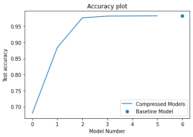

```python
from matplotlib import pyplot as plt

plt.plot(result, label='Compressed Models');
plt.title('Accuracy plot');
plt.xlabel('Model Number');
plt.ylabel('Test accuracy');
plt.scatter([6],[base_line_accuracy],label='Baseline Model');
plt.legend();
```

Here we have demonstarted the tradeoff between weight compression and model accuracy. A moderate number of singular value components is enough to emulate the performance of the baseline model.

# Part 2

Build a model similar to the baseline model above. Instead of the 5 hidden layers, replace each of them with two Dense layers such that the first layer captures 20 components in the left-singular matrix of SVD of baseline model weights, while the second layer captures the components in the right singular matrix. So, the model below will have 2(5)+1=11 layers in total.

```python
model_d_20=Sequential(
    [

    Dense(units=20,input_shape=(784,),activation=None,use_bias=False,name='layer_1_u'),
    Dense(units=1024,activation='relu',name='layer_1_v'),


    Dense(units=20,activation=None,use_bias=False,name='layer_2_u'),
    Dense(units=1024,activation='relu',name='layer_2_v'),


    Dense(units=20,activation=None,use_bias=False,name='layer_3_u'),
    Dense(units=1024,activation='relu',name='layer_3_v'),

    Dense(units=20,activation=None,use_bias=False,name='layer_4_u'),
    Dense(units=1024,activation='relu',name='layer_4_v'),

    Dense(units=20,activation=None,use_bias=False,name='layer_5_u'),
    Dense(units=1024,activation='relu',name='layer_5_v'),



    Dense(units=10,activation='softmax',name='last_layer')

    ]
)
```

Decompose the layer weights in the baseline model and load them into the model above.

```python
for i in range(len(svd_components)):
  u_20=svd_components[i][1][:,:20]
  s_20=tf.linalg.diag(svd_components[i][0])[:20,:20]
  v=tf.transpose(svd_components[i][2][:,:20])

  v_20=tf.linalg.tensordot(s_20,v,axes=1)


  #print(u_20.shape, s_20.shape,v_20.shape)
  model_d_20.layers[2*i].set_weights((u_20,))

  model_d_20.layers[2*i+1].set_weights((v_20,baseline_weights[2*i+1]))


model_d_20.layers[-1].set_weights(last_layer_weights)
```

Check if the validation accuracy of the model matches with the model_d_20 created above.

```python
compute_test_accuracy(model_d_20)
```

```
0.8839
```

It does!

Now, lets train the current model hoping we could improve the accuracy.

```python
model_d_20.compile(optimizer=Adam(learning_rate=0.00001),loss='binary_crossentropy',metrics=['accuracy']);
model_d_20_hist=model_d_20.fit(x=train_x,y=train_y,batch_size=512,epochs=20,shuffle=True,verbose=2,validation_data=(test_x,test_y))
```

```
118/118 - 1s - loss: 0.0446 - accuracy: 0.9325 - val_loss: 0.0342 - val_accuracy: 0.9466
118/118 - 1s - loss: 0.0292 - accuracy: 0.9531 - val_loss: 0.0288 - val_accuracy: 0.9528
118/118 - 1s - loss: 0.0255 - accuracy: 0.9578 - val_loss: 0.0263 - val_accuracy: 0.9565
118/118 - 1s - loss: 0.0233 - accuracy: 0.9608 - val_loss: 0.0247 - val_accuracy: 0.9592
118/118 - 1s - loss: 0.0217 - accuracy: 0.9635 - val_loss: 0.0235 - val_accuracy: 0.9617
118/118 - 1s - loss: 0.0204 - accuracy: 0.9652 - val_loss: 0.0225 - val_accuracy: 0.9634
118/118 - 1s - loss: 0.0193 - accuracy: 0.9668 - val_loss: 0.0217 - val_accuracy: 0.9646
118/118 - 0s - loss: 0.0184 - accuracy: 0.9685 - val_loss: 0.0210 - val_accuracy: 0.9660
118/118 - 0s - loss: 0.0176 - accuracy: 0.9700 - val_loss: 0.0204 - val_accuracy: 0.9672
118/118 - 1s - loss: 0.0169 - accuracy: 0.9714 - val_loss: 0.0198 - val_accuracy: 0.9681
118/118 - 0s - loss: 0.0162 - accuracy: 0.9724 - val_loss: 0.0194 - val_accuracy: 0.9683
118/118 - 0s - loss: 0.0157 - accuracy: 0.9734 - val_loss: 0.0190 - val_accuracy: 0.9685
118/118 - 0s - loss: 0.0151 - accuracy: 0.9742 - val_loss: 0.0186 - val_accuracy: 0.9694
118/118 - 1s - loss: 0.0146 - accuracy: 0.9752 - val_loss: 0.0183 - val_accuracy: 0.9701
118/118 - 1s - loss: 0.0142 - accuracy: 0.9759 - val_loss: 0.0179 - val_accuracy: 0.9707
118/118 - 0s - loss: 0.0138 - accuracy: 0.9767 - val_loss: 0.0176 - val_accuracy: 0.9708
118/118 - 0s - loss: 0.0134 - accuracy: 0.9775 - val_loss: 0.0174 - val_accuracy: 0.9717
118/118 - 1s - loss: 0.0130 - accuracy: 0.9779 - val_loss: 0.0171 - val_accuracy: 0.9721
118/118 - 0s - loss: 0.0127 - accuracy: 0.9784 - val_loss: 0.0169 - val_accuracy: 0.9728
118/118 - 0s - loss: 0.0124 - accuracy: 0.9787 - val_loss: 0.0167 - val_accuracy: 0.9731
```

As we can see in the output above, the models performance steadily increases over 20 epochs. So, we have seen that we can improve the decomposed weights by training the compressed model.

# Part 3

Now, let's see if we can make the model aware of the loss due to SVD decomposition of weights, and achieve better performance.

Design a model with custom layers such that the for every forward pass we decompose the original weights and compute the activations.

```python
def svd(weights):
  s,u,v=tf.linalg.svd(weights,compute_uv=True,full_matrices=True)
  return s,u,v

@tf.custom_gradient
def custom_op(w):
    #print('In OP')
    s,u,v = svd(w) # do SVD
    s=tf.linalg.diag(s)

    s_20=s[:20,:20]
    u_20=u[:,:20]
    v_20=tf.transpose(v[:,:20])
    compr_w=tf.linalg.tensordot(tf.linalg.tensordot(u_20,s_20,axes=1),v_20,axes=1)


    def custom_grad(dy):
        #print('In grad')
        #grad = tf.ones(shape=w.shape) # compute gradient
        return dy

    return compr_w, custom_grad


class CustomLayer(keras.layers.Layer):

    def __init__(self,units,layer_num,name,input_shape):
      super(CustomLayer, self).__init__()
      self.units=units
      self.w=tf.Variable(
            initial_value=baseline_weights[2*layer_num],
            trainable=True,
        )
      self.b=tf.Variable(
            initial_value=baseline_weights[2*layer_num+1],
            trainable=True,
        )



    def call(self, x):

        compr_w=custom_op(self.w)
        a=keras.activations.relu(tf.matmul(x,compr_w)+self.b)
        return a
```

Build the model and load weights of the baseline model using the layer number.

```python
model=Sequential(
    [

     CustomLayer(units=1024,input_shape=(784,),layer_num=0,name='layer_1'),
     CustomLayer(units=1024,input_shape=(1024,),layer_num=1,name='layer_2'),
     CustomLayer(units=1024,input_shape=(1024,),layer_num=2,name='layer_3'),
     CustomLayer(units=1024,input_shape=(1024,),layer_num=3,name='layer_4'),
     CustomLayer(units=1024,input_shape=(1024,),layer_num=4,name='layer_5'),

     Dense(units=10,input_shape=(1024,),activation='softmax',name='last_layer',weights=[last_layer_weights[0],last_layer_weights[1]])
    ]
)
```

```python
model.compile(optimizer=Adam(),loss='binary_crossentropy',metrics=['accuracy']);
```

```python
model_hist=model.fit(x=train_x,y=train_y,batch_size=1024,epochs=10,shuffle=True,verbose=2,validation_data=(test_x,test_y))
```

```
59/59 - 206s - loss: 0.0118 - accuracy: 0.9795 - val_loss: 0.0135 - val_accuracy: 0.9787
59/59 - 205s - loss: 0.0106 - accuracy: 0.9820 - val_loss: 0.0185 - val_accuracy: 0.9715
59/59 - 205s - loss: 0.0100 - accuracy: 0.9825 - val_loss: 0.0187 - val_accuracy: 0.9704
59/59 - 205s - loss: 0.0101 - accuracy: 0.9828 - val_loss: 0.0162 - val_accuracy: 0.9756
59/59 - 205s - loss: 0.0096 - accuracy: 0.9833 - val_loss: 0.0146 - val_accuracy: 0.9788
59/59 - 205s - loss: 0.0087 - accuracy: 0.9849 - val_loss: 0.0163 - val_accuracy: 0.9753
59/59 - 205s - loss: 0.0080 - accuracy: 0.9858 - val_loss: 0.0147 - val_accuracy: 0.9770
59/59 - 204s - loss: 0.0085 - accuracy: 0.9852 - val_loss: 0.0155 - val_accuracy: 0.9770
59/59 - 204s - loss: 0.0077 - accuracy: 0.9868 - val_loss: 0.0156 - val_accuracy: 0.9772
59/59 - 204s - loss: 0.0070 - accuracy: 0.9876 - val_loss: 0.0177 - val_accuracy: 0.9747
```

```python
model.summary()
```

```
Model: "sequential_38"
_________________________________________________________________
Layer (type)                 Output Shape              Param #
=================================================================
custom_layer_87 (CustomLayer (None, 1024)              803840
_________________________________________________________________
custom_layer_88 (CustomLayer (None, 1024)              1049600
_________________________________________________________________
custom_layer_89 (CustomLayer (None, 1024)              1049600
_________________________________________________________________
custom_layer_90 (CustomLayer (None, 1024)              1049600
_________________________________________________________________
custom_layer_91 (CustomLayer (None, 1024)              1049600
_________________________________________________________________
last_layer (Dense)           (None, 10)                10250
=================================================================
Total params: 5,012,490
Trainable params: 5,012,490
Non-trainable params: 0
_________________________________________________________________
```

As we can see from the output, we could achieve resonable validation accuracy by making the model aware of the decomposition procedure.

# Part 4

The dataset is large for this question. So, I have loaded the dataset on Google drive and imported it from there.

```python
from google.colab import drive
drive.mount('/content/drive')
```

```python
import os
path='/content/drive/My Drive/dl-assignment-3-part-4/'

tr_path=path+'/tr/'
val_path=path+'/v/'
```

```python
tr_files=os.listdir(tr_path)
te_files=os.listdir(te_path)
val_files=os.listdir(val_path)
```

```python
trx=sorted([ file for file in tr_files if file.startswith('trx')])
trs=sorted([ file for file in tr_files if file.startswith('trs')])
trn=sorted([ file for file in tr_files if file.startswith('trn')])
```

```python
vx=sorted([ file for file in val_files if file.startswith('vx')])
vs=sorted([ file for file in val_files if file.startswith('vs')])
vn=sorted([ file for file in val_files if file.startswith('vn')])
```

Lets hear an audio in the dataset-

```python
import librosa
import IPython.display as ipd

s, sr=librosa.load(tr_path+trx[0], sr=None)
ipd.Audio(s, rate=sr)
```

[interactive chart not shown]

First lets compute the complex and magintude spectrum of the audio files in the training and validation aset.

```python
from concurrent.futures import ProcessPoolExecutor
import numpy as np
from tqdm import tqdm

def process_data(path,files):

  spect=[]
  mag_spect=[]

  for aud in tqdm(files):
    s, sr=librosa.load(path+aud, sr=None)
    S=librosa.stft(s, n_fft=1024, hop_length=512)

    spect.append(S)

    mod_S=np.abs(S)
    mag_spect.append(mod_S)

    del s,S,mod_S

  return spect,mag_spect
```

```python
"""
from concurrent.futures import ThreadPoolExecutor

with ThreadPoolExecutor() as executor:
  compute_X_thread=executor.submit(process_data,tr_path,trx)
  compute_S_thread=executor.submit(process_data,tr_path,trs)
  compute_N_thread=executor.submit(process_data,tr_path,trn)


  cmp_X,X=compute_X_thread.result()
  cmp_S,S=compute_S_thread.result()
  cmp_N,N=compute_N_thread.result()

"""

cmp_X,X=process_data(tr_path,trx)
cmp_S,S=process_data(tr_path,trs)
cmp_N,N=process_data(tr_path,trn)
val_cmp_X,val_X=process_data(val_path,vx)
val_cmp_S,val_S=process_data(val_path,vs)
val_cmp_N,val_N=process_data(val_path,vn)
```

```python
"""
with ThreadPoolExecutor() as executor:
  compute_X_thread=executor.submit(process_data,val_path,vx)
  compute_S_thread=executor.submit(process_data,val_path,vs)
  compute_N_thread=executor.submit(process_data,val_path,vn)


  val_cmp_X,val_X=compute_X_thread.result()
  val_cmp_S,val_S=compute_S_thread.result()
  val_cmp_N,val_N=compute_N_thread.result()
"""
```

Now that we have the spectrogramns of the noise, source and mixed signals in the training and validation set, lets compute the IBMs for each mixed signal using the corresponding source and noise signals.

```python
M=[]
for sign, noise in zip(S,N):
  M.append((sign>noise)*1)

val_M=[]

for sign, noise in zip(val_S,val_N):
  val_M.append((sign>noise)*1)
```

Now, lets transpose the spectrograms such that the sequences are along the rows.

```python
for i in range(1200):
  X[i]=X[i].T
  S[i]=S[i].T
  N[i]=N[i].T
  M[i]=M[i].T
```

```python
for i in range(1200):
  val_X[i]=val_X[i].T
  val_S[i]=val_S[i].T
  val_N[i]=val_N[i].T
  val_M[i]=val_M[i].T
```

Now, let pad the spectrograms such that they have uniform shape.

```python
max_length_train=float('-inf')

for i in range(1200):
  max_length_train=max(max_length_train,X[i].shape[0])

print(max_length_train)

max_length_val=float('-inf')

for i in range(1200):
  max_length_val=max(max_length_train,val_X[i].shape[0])

print(max_length_val)
```

```
178
178
```

```python
import numpy as np

for i in range(1200):

  X[i]=np.pad(X[i],((0,max_length_train-X[i].shape[0]),(0,0)),'constant')
  S[i]=np.pad(S[i],((0,max_length_train-S[i].shape[0]),(0,0)),'constant')
  N[i]=np.pad(N[i],((0,max_length_train-N[i].shape[0]),(0,0)),'constant')
  M[i]=np.pad(M[i],((0,max_length_train-M[i].shape[0]),(0,0)),'constant')
```

```python
X[0].shape
```

```
(178, 513)
```

```python
for i in range(1200):
  val_X[i]=np.pad(val_X[i],((0,max_length_val-val_X[i].shape[0]),(0,0)),'constant')
  val_S[i]=np.pad(val_S[i],((0,max_length_val-val_S[i].shape[0]),(0,0)),'constant')
  val_N[i]=np.pad(val_N[i],((0,max_length_val-val_N[i].shape[0]),(0,0)),'constant')
  val_M[i]=np.pad(val_M[i],((0,max_length_val-val_M[i].shape[0]),(0,0)),'constant')
```

```python
val_X[0].shape
```

```
(178, 513)
```

```python
X=np.array(X)
S=np.array(S)
N=np.array(N)
M=np.array(M)
```

```python
val_X=np.array(val_X)
val_S=np.array(val_S)
val_N=np.array(val_N)
val_M=np.array(val_M)
```

```python
M.shape
```

```
(1200, 178, 513)
```

Now, lets train a model with three LSTM layers.

```python
from tensorflow.keras.models import Sequential
from tensorflow.keras.layers import Activation,Dense,LSTM,Input
from tensorflow.keras.optimizers import Adam
from tensorflow.keras.metrics import mean_squared_error
```

```python
model=Sequential([
                  Input(shape=(None,513)),
                  LSTM(activation='tanh',units=512,return_sequences=True,name='layer_1'),
                  LSTM(activation='tanh',units=512,return_sequences=True,name='layer_2'),
                  LSTM(activation='sigmoid',units=513,return_sequences=True,name='layer_3')
                  ])
```

```
WARNING:tensorflow:Layer layer_3 will not use cuDNN kernel since it doesn't meet the cuDNN kernel criteria. It will use generic GPU kernel as fallback when running on GPU
```

```python
model.compile(optimizer=Adam(),loss=mean_squared_error,metrics=['mean_squared_error']);
```

```python
model.summary()
```

```
Model: "sequential_3"
_________________________________________________________________
Layer (type)                 Output Shape              Param #
=================================================================
layer_1 (LSTM)               (None, None, 512)         2101248
_________________________________________________________________
layer_2 (LSTM)               (None, None, 512)         2099200
_________________________________________________________________
layer_3 (LSTM)               (None, None, 513)         2105352
=================================================================
Total params: 6,305,800
Trainable params: 6,305,800
Non-trainable params: 0
_________________________________________________________________
```

```python
model_history=model.fit(x=X,y=M,batch_size=32,epochs=100,shuffle=True,verbose=2, validation_data=(val_X,val_M))
```

```
38/38 - 14s - loss: 0.1522 - mean_squared_error: 0.1522 - val_loss: 0.1319 - val_mean_squared_error: 0.1319
38/38 - 14s - loss: 0.1218 - mean_squared_error: 0.1218 - val_loss: 0.1110 - val_mean_squared_error: 0.1110
38/38 - 14s - loss: 0.1083 - mean_squared_error: 0.1083 - val_loss: 0.1056 - val_mean_squared_error: 0.1056
38/38 - 14s - loss: 0.1024 - mean_squared_error: 0.1024 - val_loss: 0.0966 - val_mean_squared_error: 0.0966
38/38 - 14s - loss: 0.0956 - mean_squared_error: 0.0956 - val_loss: 0.0932 - val_mean_squared_error: 0.0932
38/38 - 14s - loss: 0.0915 - mean_squared_error: 0.0915 - val_loss: 0.0869 - val_mean_squared_error: 0.0869
38/38 - 14s - loss: 0.0869 - mean_squared_error: 0.0869 - val_loss: 0.0831 - val_mean_squared_error: 0.0831
38/38 - 14s - loss: 0.0845 - mean_squared_error: 0.0845 - val_loss: 0.0865 - val_mean_squared_error: 0.0865
38/38 - 14s - loss: 0.0825 - mean_squared_error: 0.0825 - val_loss: 0.0800 - val_mean_squared_error: 0.0800
38/38 - 14s - loss: 0.0799 - mean_squared_error: 0.0799 - val_loss: 0.0788 - val_mean_squared_error: 0.0788
38/38 - 14s - loss: 0.0787 - mean_squared_error: 0.0787 - val_loss: 0.0779 - val_mean_squared_error: 0.0779
38/38 - 14s - loss: 0.0772 - mean_squared_error: 0.0772 - val_loss: 0.0770 - val_mean_squared_error: 0.0770
38/38 - 14s - loss: 0.0756 - mean_squared_error: 0.0756 - val_loss: 0.0762 - val_mean_squared_error: 0.0762
38/38 - 14s - loss: 0.0749 - mean_squared_error: 0.0749 - val_loss: 0.0749 - val_mean_squared_error: 0.0749
38/38 - 14s - loss: 0.0735 - mean_squared_error: 0.0735 - val_loss: 0.0748 - val_mean_squared_error: 0.0748
38/38 - 14s - loss: 0.0724 - mean_squared_error: 0.0724 - val_loss: 0.0751 - val_mean_squared_error: 0.0751
38/38 - 14s - loss: 0.0716 - mean_squared_error: 0.0716 - val_loss: 0.0735 - val_mean_squared_error: 0.0735
38/38 - 14s - loss: 0.0709 - mean_squared_error: 0.0709 - val_loss: 0.0725 - val_mean_squared_error: 0.0725
38/38 - 14s - loss: 0.0697 - mean_squared_error: 0.0697 - val_loss: 0.0729 - val_mean_squared_error: 0.0729
38/38 - 14s - loss: 0.0685 - mean_squared_error: 0.0685 - val_loss: 0.0719 - val_mean_squared_error: 0.0719
38/38 - 14s - loss: 0.0676 - mean_squared_error: 0.0676 - val_loss: 0.0720 - val_mean_squared_error: 0.0720
38/38 - 14s - loss: 0.0672 - mean_squared_error: 0.0672 - val_loss: 0.0724 - val_mean_squared_error: 0.0724
38/38 - 14s - loss: 0.0667 - mean_squared_error: 0.0667 - val_loss: 0.0743 - val_mean_squared_error: 0.0743
38/38 - 14s - loss: 0.0661 - mean_squared_error: 0.0661 - val_loss: 0.0720 - val_mean_squared_error: 0.0720
38/38 - 14s - loss: 0.0657 - mean_squared_error: 0.0657 - val_loss: 0.0718 - val_mean_squared_error: 0.0718
38/38 - 14s - loss: 0.0645 - mean_squared_error: 0.0645 - val_loss: 0.0707 - val_mean_squared_error: 0.0707
38/38 - 14s - loss: 0.0631 - mean_squared_error: 0.0631 - val_loss: 0.0702 - val_mean_squared_error: 0.0702
38/38 - 14s - loss: 0.0624 - mean_squared_error: 0.0624 - val_loss: 0.0696 - val_mean_squared_error: 0.0696
38/38 - 14s - loss: 0.0616 - mean_squared_error: 0.0616 - val_loss: 0.0699 - val_mean_squared_error: 0.0699
38/38 - 14s - loss: 0.0616 - mean_squared_error: 0.0616 - val_loss: 0.0698 - val_mean_squared_error: 0.0698
38/38 - 14s - loss: 0.0610 - mean_squared_error: 0.0610 - val_loss: 0.0706 - val_mean_squared_error: 0.0706
38/38 - 14s - loss: 0.0608 - mean_squared_error: 0.0608 - val_loss: 0.0704 - val_mean_squared_error: 0.0704
38/38 - 15s - loss: 0.0612 - mean_squared_error: 0.0612 - val_loss: 0.0698 - val_mean_squared_error: 0.0698
38/38 - 14s - loss: 0.0603 - mean_squared_error: 0.0603 - val_loss: 0.0693 - val_mean_squared_error: 0.0693
38/38 - 14s - loss: 0.0595 - mean_squared_error: 0.0595 - val_loss: 0.0696 - val_mean_squared_error: 0.0696
38/38 - 14s - loss: 0.0589 - mean_squared_error: 0.0589 - val_loss: 0.0703 - val_mean_squared_error: 0.0703
38/38 - 14s - loss: 0.0582 - mean_squared_error: 0.0582 - val_loss: 0.0687 - val_mean_squared_error: 0.0687
38/38 - 14s - loss: 0.0573 - mean_squared_error: 0.0573 - val_loss: 0.0683 - val_mean_squared_error: 0.0683
38/38 - 14s - loss: 0.0567 - mean_squared_error: 0.0567 - val_loss: 0.0680 - val_mean_squared_error: 0.0680
38/38 - 14s - loss: 0.0563 - mean_squared_error: 0.0563 - val_loss: 0.0685 - val_mean_squared_error: 0.0685
```

[output cut: 45 more lines]

```
38/38 - 15s - loss: 0.0467 - mean_squared_error: 0.0467 - val_loss: 0.0688 - val_mean_squared_error: 0.0688
38/38 - 14s - loss: 0.0466 - mean_squared_error: 0.0466 - val_loss: 0.0688 - val_mean_squared_error: 0.0688
38/38 - 14s - loss: 0.0465 - mean_squared_error: 0.0465 - val_loss: 0.0691 - val_mean_squared_error: 0.0691
38/38 - 15s - loss: 0.0463 - mean_squared_error: 0.0463 - val_loss: 0.0686 - val_mean_squared_error: 0.0686
38/38 - 14s - loss: 0.0461 - mean_squared_error: 0.0461 - val_loss: 0.0693 - val_mean_squared_error: 0.0693
38/38 - 14s - loss: 0.0460 - mean_squared_error: 0.0460 - val_loss: 0.0690 - val_mean_squared_error: 0.0690
38/38 - 15s - loss: 0.0459 - mean_squared_error: 0.0459 - val_loss: 0.0691 - val_mean_squared_error: 0.0691
38/38 - 14s - loss: 0.0459 - mean_squared_error: 0.0459 - val_loss: 0.0695 - val_mean_squared_error: 0.0695
38/38 - 14s - loss: 0.0459 - mean_squared_error: 0.0459 - val_loss: 0.0694 - val_mean_squared_error: 0.0694
38/38 - 15s - loss: 0.0482 - mean_squared_error: 0.0482 - val_loss: 0.0709 - val_mean_squared_error: 0.0709
38/38 - 14s - loss: 0.0479 - mean_squared_error: 0.0479 - val_loss: 0.0688 - val_mean_squared_error: 0.0688
38/38 - 15s - loss: 0.0466 - mean_squared_error: 0.0466 - val_loss: 0.0687 - val_mean_squared_error: 0.0687
38/38 - 15s - loss: 0.0459 - mean_squared_error: 0.0459 - val_loss: 0.0686 - val_mean_squared_error: 0.0686
38/38 - 14s - loss: 0.0455 - mean_squared_error: 0.0455 - val_loss: 0.0690 - val_mean_squared_error: 0.0690
38/38 - 14s - loss: 0.0453 - mean_squared_error: 0.0453 - val_loss: 0.0694 - val_mean_squared_error: 0.0694
```

Let's plot the losses-

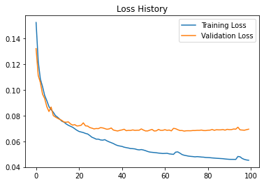

```python
from matplotlib import pyplot as plt


loss_hist=model_history.history['mean_squared_error']
val_loss_hist=model_history.history['val_mean_squared_error']
plt.plot(loss_hist,label='Training Loss');
plt.plot(val_loss_hist,label='Validation Loss');
plt.title('Loss History');
plt.legend();
```

```python
model.save(filepath='./rnn_denoise.h5')
```

Let's predict the IBMs for mixed signals in the training set-

```python
M_pred=model.predict(x=X,batch_size=32,verbose=0)
```

```python
M_pred=M_pred.transpose((0,2,1))
```

Now, let's generate the denoised outputs for mixed signals in the training set. The outputs are stored inside a directory in Google drive.

```python
sub_dir='train_denoise/'
com_name='train_'


for i in tqdm(range(len(M_pred))):

  recovered_spect=M_pred[i][:,:cmp_X[i].shape[1]]*cmp_X[i]
  recovered_signal=librosa.istft(recovered_spect,hop_length=512)
  librosa.output.write_wav(path+sub_dir+com_name+f'{i+1}.wav',recovered_signal, sr)

  del recovered_signal, recovered_spect
```

Lets repeat the same procedure as above to generate the denosied outputs for mixed signals in the validation set -

```python
val_M_pred=model.predict(x=val_X,batch_size=32,verbose=0)
```

```python
val_M_pred=val_M_pred.transpose((0,2,1))
```

```python
sub_dir='val_denoise/'
com_name='val_'


for i in tqdm(range(len(val_M_pred))):

  recovered_spect=val_M_pred[i][:,:val_cmp_X[i].shape[1]]*val_cmp_X[i]
  recovered_signal=librosa.istft(recovered_spect,hop_length=512)
  librosa.output.write_wav(path+sub_dir+com_name+f'{i+1}.wav',recovered_signal, sr)

  del recovered_signal, recovered_spect
```

Finally, Lets repeat the same steps as above to generate the denosied outputs for signals in the test set -

```python
te_path=path+'/te/'
te_files=os.listdir(te_path)
tex=sorted([ file for file in te_files if file.startswith('tex')])
```

```python
import librosa
import IPython.display as ipd

s, sr=librosa.load(te_path+tex[0], sr=None)
ipd.Audio(s, rate=sr)
```

[interactive chart not shown]

Process data-

```python
te_cmp_X, te_X=process_data(te_path,tex)
```

```python
for i in range(len(te_X)):
  te_X[i]=te_X[i].T
```

```python
max_length_test=float('-inf')

for i in range(len(te_X)):
  max_length_test=max(max_length_test,te_X[i].shape[0])


print(max_length_test)
```

```
195
```

```python
for i in range(len(te_X)):

  te_X[i]=np.pad(te_X[i],((0,max_length_test-te_X[i].shape[0]),(0,0)),'constant')
```

```python
te_X=np.array(te_X)
```

```python
te_X.shape
```

```
(400, 195, 513)
```

Generate predictions-

```python
te_M_pred=model.predict(x=te_X,batch_size=32,verbose=0).transpose((0,2,1))
```

Denoised signal in the test set-

```python
recovered_spect=te_M_pred[0][:,:te_cmp_X[0].shape[1]]*te_cmp_X[0]
recovered_signal=librosa.istft(recovered_spect,hop_length=512)
ipd.Audio(recovered_signal, rate=sr)
```

[interactive chart not shown]

Store the denoised signals on Google drive-

```python
sub_dir='test_denoise/'
com_name='test_'


for i in tqdm(range(len(te_M_pred))):

  recovered_spect=te_M_pred[i][:,:te_cmp_X[i].shape[1]]*te_cmp_X[i]
  recovered_signal=librosa.istft(recovered_spect,hop_length=512)
  librosa.output.write_wav(path+sub_dir+com_name+f'{i+1}.wav',recovered_signal, sr)

  del recovered_signal, recovered_spect
```

Compute and plot the dsitribution of SNRs of denoised audios in the training and validation set.

```python
import librosa
import tqdm
import numpy as np


def evaluate(org_path, rec_path,keyword=None):

  result=[]

  def comp_snr(org,rec):

    if len(org)<len(rec):
      rec=rec[:len(org)]

    elif len(org)>len(rec):
      org=org[:len(rec)]


    num=1e-20

    for i in range(len(org)):
      num+=org[i]**2

    denom=1e-20

    for i in range(len(org)):
      diff=org[i]-rec[i]
      denom+=diff**2

    return 10*np.log10(num/denom)


  org_files=[file for file in sorted(os.listdir(org_path)) if file.startswith(keyword)]

  rec_files=sorted(os.listdir(rec_path),key=lambda x: int(x.split('.')[0].split('_')[1]))

  for org_file,rec_file in tqdm.tqdm(zip(sorted(org_files),rec_files)):
    org,_=librosa.load(org_path+org_file, sr=None)
    rec,_=librosa.load(rec_path+rec_file, sr=None)

    snr_value=comp_snr(org,rec)
    print(snr_value)
    result.append(snr_value)

  return result


org_path=path+'tr/'
rec_path=path+'train_denoise/'

train_snrs=evaluate(org_path,rec_path,'trs')
```

```python
org_path=path+'v/'
rec_path=path+'val_denoise/'

val_snrs=evaluate(org_path,rec_path,'vs')
```

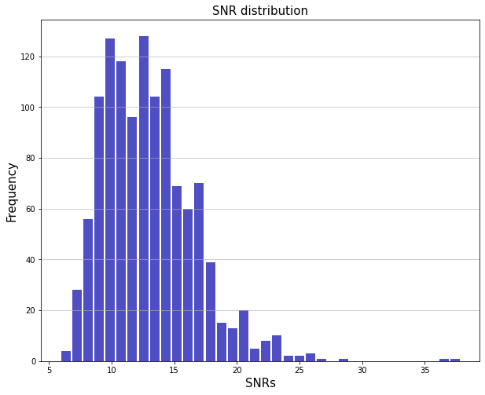

```python
from matplotlib import pyplot as plt

def plot_histogram(arr):
    plt.figure(figsize=[10,8])
    plt.hist(x=arr, bins='auto', color='#0504aa',alpha=0.7, rwidth=0.85)
    plt.grid(axis='y', alpha=0.75)
    plt.xlabel('SNRs',fontsize=15)
    plt.ylabel('Frequency',fontsize=15)
    plt.xticks(fontsize=10)
    plt.yticks(fontsize=10)
    plt.title('SNR distribution',fontsize=15)
    plt.show()

plot_histogram(train_snrs)
```

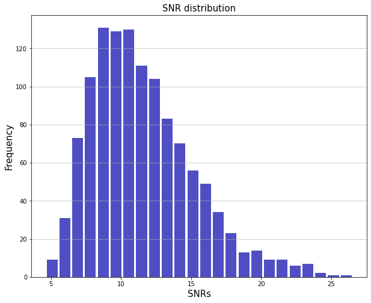

```python
plot_histogram(val_snrs)
```

As we can see, our model performed decently on both the sets- Highest SNR>=35 in the training set, while highest SNR>=25 in the validation set

# Part 5

Import the required libraries-

```python
import numpy as np
from sklearn.utils import shuffle
from sklearn.preprocessing import MinMaxScaler,OneHotEncoder
from sklearn.model_selection import train_test_split
import tensorflow as tf
from tensorflow import keras
from tensorflow.keras.models import Sequential
from tensorflow.keras.layers import Dense, LSTM, Input
from tensorflow.keras.optimizers import Adam
from tensorflow.keras.metrics import mean_squared_error
from matplotlib import pyplot as plt
import IPython.display as ipd
```

Import the dataset-

```python
mnist = tf.keras.datasets.mnist
data=mnist.load_data()
```

```
Downloading data from https://storage.googleapis.com/tensorflow/tf-keras-datasets/mnist.npz
```

```python
train_x=data[0][0]
train_y=data[0][1].reshape(-1,1)
```

Process the data- Scale training pixel values to range (0,1) and encode the labels.

```python
# Process the data

def clean_data(x,y):


  # Flatten the data
  samples=[]
  for sample in x[:]:
    samples.append(sample.flatten())

  x=np.array(samples)

  # Encode the labels
  enc=OneHotEncoder()

  enc.fit(y)

  onehotlabels = enc.transform(y).toarray()
  y=onehotlabels

  # Shuffle the data
  x,y=shuffle(x,y)

  # Scale the data
  scaler=MinMaxScaler(feature_range=(0,1))

  x=scaler.fit_transform(x)

  print(x.shape)

  final_x=[]
  for i in range(len(x)):
    final_x.append(x[i].reshape(28,28))

  final_x=np.array(final_x)

  print(final_x.shape)


  return final_x,y



train_x,train_y=clean_data(train_x,train_y)
```

```
(60000, 784)
(60000, 28, 28)
```

Let's explore how the images would like if we divide them into sequence of 16 patches.

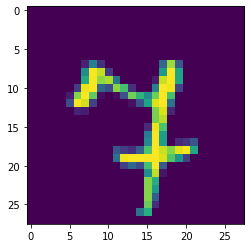

```python
from matplotlib import pyplot as plt

plt.imshow(train_x[0]);
```

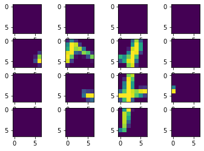

```python
fig, axes=plt.subplots(nrows=4,ncols=4)


sample=[]
for i in range(0,train_x[0].shape[0],7):
  for j in range(0,train_x[0].shape[1],7):
    axes[i//7,j//7].imshow(train_x[0][i:i+7,j:j+7])
    sample.append(train_x[0][i:i+7,j:j+7].flatten())
```

```python
sample=np.array(sample)
sample.shape
```

```
(16, 49)
```

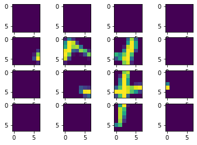

```python
fig, axes=plt.subplots(nrows=4,ncols=4)

for i in range(len(sample)):
  x=i//4
  y=i%4
  axes[x,y].imshow(sample[i].reshape(7,7))
```

Lets divide all the images in the training set into patches of 16 sequences-

```python
from tqdm import tqdm


def div_frames(data):

  processed_data=[]
  for n in tqdm(range(len(data))):
    sample=[]
    for i in range(0,data[n].shape[0],7):
      for j in range(0,data[n].shape[1],7):

        sample.append(data[n][i:i+7,j:j+7].flatten())

    sample=np.array(sample)
    processed_data.append(sample)
    del sample

  return np.array(processed_data)


train_x=div_frames(train_x)
```

```python
train_x.shape,train_y.shape
```

```
((60000, 16, 49), (60000, 10))
```

Lets process the data such that each image in the training set is a sequence of first 15 patches of the original image while the labels are last 15 patches in the original image.

```python
def preprocess(data):

  x=[]
  y=[]
  for i in tqdm(range(len(data))):
    x.append(data[i][:-1,:])
    y.append(data[i][1:,:])

  x=np.array(x)
  y=np.array(y)

  return x,y

x,y=preprocess(train_x)
```

Now, lets build and train a sequential model with 2 LSTM layers and one Dense layer.

```python
model=Sequential([

                  Input(shape=(None,49)),
                  LSTM(activation='tanh',units=64,return_sequences=True,name='layer_1'),
                  LSTM(activation='tanh',units=64,return_sequences=True,name='layer_2'),
                  Dense(activation='sigmoid',units=49,name='final_layer',kernel_initializer=keras.initializers.HeNormal)

                ])
```

```python
model.compile(optimizer=Adam(),loss=mean_squared_error,metrics=['mean_squared_error']);
```

```python
model.summary()
```

```
Model: "sequential"
_________________________________________________________________
Layer (type)                 Output Shape              Param #
=================================================================
layer_1 (LSTM)               (None, None, 64)          29184
_________________________________________________________________
layer_2 (LSTM)               (None, None, 64)          33024
_________________________________________________________________
final_layer (Dense)          (None, None, 49)          3185
=================================================================
Total params: 65,393
Trainable params: 65,393
Non-trainable params: 0
_________________________________________________________________
```

```python
model_hist=model.fit(x=x,y=y,batch_size=1024,epochs=100,shuffle=True,verbose=2, validation_split=0.1)
```

```
53/53 - 1s - loss: 0.1583 - mean_squared_error: 0.1583 - val_loss: 0.1240 - val_mean_squared_error: 0.1240
53/53 - 1s - loss: 0.1172 - mean_squared_error: 0.1172 - val_loss: 0.1113 - val_mean_squared_error: 0.1113
53/53 - 1s - loss: 0.1057 - mean_squared_error: 0.1057 - val_loss: 0.0983 - val_mean_squared_error: 0.0983
53/53 - 1s - loss: 0.0913 - mean_squared_error: 0.0913 - val_loss: 0.0858 - val_mean_squared_error: 0.0858
53/53 - 1s - loss: 0.0820 - mean_squared_error: 0.0820 - val_loss: 0.0790 - val_mean_squared_error: 0.0790
53/53 - 1s - loss: 0.0769 - mean_squared_error: 0.0769 - val_loss: 0.0749 - val_mean_squared_error: 0.0749
53/53 - 1s - loss: 0.0733 - mean_squared_error: 0.0733 - val_loss: 0.0716 - val_mean_squared_error: 0.0716
53/53 - 1s - loss: 0.0702 - mean_squared_error: 0.0702 - val_loss: 0.0689 - val_mean_squared_error: 0.0689
53/53 - 1s - loss: 0.0674 - mean_squared_error: 0.0674 - val_loss: 0.0660 - val_mean_squared_error: 0.0660
53/53 - 1s - loss: 0.0648 - mean_squared_error: 0.0648 - val_loss: 0.0636 - val_mean_squared_error: 0.0636
53/53 - 1s - loss: 0.0626 - mean_squared_error: 0.0626 - val_loss: 0.0616 - val_mean_squared_error: 0.0616
53/53 - 1s - loss: 0.0607 - mean_squared_error: 0.0607 - val_loss: 0.0602 - val_mean_squared_error: 0.0602
53/53 - 1s - loss: 0.0591 - mean_squared_error: 0.0591 - val_loss: 0.0584 - val_mean_squared_error: 0.0584
53/53 - 1s - loss: 0.0577 - mean_squared_error: 0.0577 - val_loss: 0.0571 - val_mean_squared_error: 0.0571
53/53 - 1s - loss: 0.0565 - mean_squared_error: 0.0565 - val_loss: 0.0560 - val_mean_squared_error: 0.0560
53/53 - 1s - loss: 0.0554 - mean_squared_error: 0.0554 - val_loss: 0.0552 - val_mean_squared_error: 0.0552
53/53 - 1s - loss: 0.0544 - mean_squared_error: 0.0544 - val_loss: 0.0541 - val_mean_squared_error: 0.0541
53/53 - 1s - loss: 0.0535 - mean_squared_error: 0.0535 - val_loss: 0.0532 - val_mean_squared_error: 0.0532
53/53 - 1s - loss: 0.0527 - mean_squared_error: 0.0527 - val_loss: 0.0524 - val_mean_squared_error: 0.0524
53/53 - 1s - loss: 0.0518 - mean_squared_error: 0.0518 - val_loss: 0.0516 - val_mean_squared_error: 0.0516
53/53 - 1s - loss: 0.0511 - mean_squared_error: 0.0511 - val_loss: 0.0508 - val_mean_squared_error: 0.0508
53/53 - 1s - loss: 0.0503 - mean_squared_error: 0.0503 - val_loss: 0.0501 - val_mean_squared_error: 0.0501
53/53 - 1s - loss: 0.0496 - mean_squared_error: 0.0496 - val_loss: 0.0495 - val_mean_squared_error: 0.0495
53/53 - 1s - loss: 0.0490 - mean_squared_error: 0.0490 - val_loss: 0.0488 - val_mean_squared_error: 0.0488
53/53 - 1s - loss: 0.0484 - mean_squared_error: 0.0484 - val_loss: 0.0483 - val_mean_squared_error: 0.0483
53/53 - 1s - loss: 0.0478 - mean_squared_error: 0.0478 - val_loss: 0.0477 - val_mean_squared_error: 0.0477
53/53 - 1s - loss: 0.0472 - mean_squared_error: 0.0472 - val_loss: 0.0472 - val_mean_squared_error: 0.0472
53/53 - 1s - loss: 0.0467 - mean_squared_error: 0.0467 - val_loss: 0.0466 - val_mean_squared_error: 0.0466
53/53 - 1s - loss: 0.0462 - mean_squared_error: 0.0462 - val_loss: 0.0462 - val_mean_squared_error: 0.0462
53/53 - 1s - loss: 0.0458 - mean_squared_error: 0.0458 - val_loss: 0.0459 - val_mean_squared_error: 0.0459
53/53 - 1s - loss: 0.0454 - mean_squared_error: 0.0454 - val_loss: 0.0453 - val_mean_squared_error: 0.0453
53/53 - 1s - loss: 0.0450 - mean_squared_error: 0.0450 - val_loss: 0.0449 - val_mean_squared_error: 0.0449
53/53 - 1s - loss: 0.0446 - mean_squared_error: 0.0446 - val_loss: 0.0446 - val_mean_squared_error: 0.0446
53/53 - 1s - loss: 0.0442 - mean_squared_error: 0.0442 - val_loss: 0.0442 - val_mean_squared_error: 0.0442
53/53 - 1s - loss: 0.0439 - mean_squared_error: 0.0439 - val_loss: 0.0439 - val_mean_squared_error: 0.0439
53/53 - 1s - loss: 0.0436 - mean_squared_error: 0.0436 - val_loss: 0.0436 - val_mean_squared_error: 0.0436
53/53 - 1s - loss: 0.0433 - mean_squared_error: 0.0433 - val_loss: 0.0434 - val_mean_squared_error: 0.0434
53/53 - 1s - loss: 0.0430 - mean_squared_error: 0.0430 - val_loss: 0.0430 - val_mean_squared_error: 0.0430
53/53 - 1s - loss: 0.0427 - mean_squared_error: 0.0427 - val_loss: 0.0428 - val_mean_squared_error: 0.0428
53/53 - 1s - loss: 0.0424 - mean_squared_error: 0.0424 - val_loss: 0.0425 - val_mean_squared_error: 0.0425
```

[output cut: 45 more lines]

```
53/53 - 1s - loss: 0.0353 - mean_squared_error: 0.0353 - val_loss: 0.0357 - val_mean_squared_error: 0.0357
53/53 - 1s - loss: 0.0352 - mean_squared_error: 0.0352 - val_loss: 0.0355 - val_mean_squared_error: 0.0355
53/53 - 1s - loss: 0.0351 - mean_squared_error: 0.0351 - val_loss: 0.0355 - val_mean_squared_error: 0.0355
53/53 - 1s - loss: 0.0351 - mean_squared_error: 0.0351 - val_loss: 0.0353 - val_mean_squared_error: 0.0353
53/53 - 1s - loss: 0.0350 - mean_squared_error: 0.0350 - val_loss: 0.0353 - val_mean_squared_error: 0.0353
53/53 - 1s - loss: 0.0349 - mean_squared_error: 0.0349 - val_loss: 0.0352 - val_mean_squared_error: 0.0352
53/53 - 1s - loss: 0.0348 - mean_squared_error: 0.0348 - val_loss: 0.0351 - val_mean_squared_error: 0.0351
53/53 - 1s - loss: 0.0348 - mean_squared_error: 0.0348 - val_loss: 0.0350 - val_mean_squared_error: 0.0350
53/53 - 1s - loss: 0.0347 - mean_squared_error: 0.0347 - val_loss: 0.0350 - val_mean_squared_error: 0.0350
53/53 - 1s - loss: 0.0346 - mean_squared_error: 0.0346 - val_loss: 0.0349 - val_mean_squared_error: 0.0349
53/53 - 1s - loss: 0.0345 - mean_squared_error: 0.0345 - val_loss: 0.0348 - val_mean_squared_error: 0.0348
53/53 - 1s - loss: 0.0345 - mean_squared_error: 0.0345 - val_loss: 0.0348 - val_mean_squared_error: 0.0348
53/53 - 1s - loss: 0.0344 - mean_squared_error: 0.0344 - val_loss: 0.0347 - val_mean_squared_error: 0.0347
53/53 - 1s - loss: 0.0344 - mean_squared_error: 0.0344 - val_loss: 0.0346 - val_mean_squared_error: 0.0346
53/53 - 1s - loss: 0.0342 - mean_squared_error: 0.0342 - val_loss: 0.0346 - val_mean_squared_error: 0.0346
```

Now, lets write a few helper functions to evalute our model-

```python
def predict(sample):
  sample=sample[tf.newaxis,:,:]

  for i in range(8):
    prediction=model.predict(sample,batch_size=1)
    sample=np.append(sample,prediction[0][-1].reshape((1,49))[tf.newaxis,:,:],axis=1)


  pred_image=sample[0]

  recon_image=np.zeros((28,28))

  seq=0
  for i in range(0,28,7):
    for j in range(0,28,7):

      recon_image[i:i+7,j:j+7]=pred_image[seq].reshape(7,7)
      seq+=1

  return recon_image
```

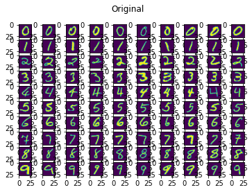

```python
def evaluate(data,indexes):



  #print(indexes)

  fig, axes=plt.subplots(nrows=10,ncols=10)
  fig.suptitle('Predicted')

  for i in range(100):
    row=i//10
    column=i%10

    sample=data[indexes[row][column]][:8,:]
    predicted_image=predict(sample)

    axes[row,column].imshow(predicted_image)



indexes={i:[] for i in range(10)}

for i in range(len(train_y)):
  key=np.argmax(train_y[i])
  if len(indexes[key])<10:
    indexes[key].append(i)



fig, axes=plt.subplots(nrows=10,ncols=10)
fig.suptitle('Original')

for i in range(10):
  for j in range(10):
    img=np.zeros((28,28))
    seq=0
    for k in range(0,28,7):
      for l in range(0,28,7):

        img[k:k+7,l:l+7]=train_x[indexes[i][j]][seq].reshape(7,7)
        seq+=1

    axes[i,j].imshow(img)
```

Lets evaluate the model on the training set-

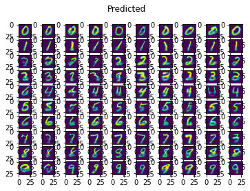

```python
evaluate(x,indexes)
```

Looks like our model is performing decently.

Now, lets evaluate our model on the test set-

```python
test_x=data[1][0]
test_y=data[1][1].reshape(-1,1)
```

```python
test_x,test_y=clean_data(test_x,test_y)
```

```
(10000, 784)
(10000, 28, 28)
```

```python
test_x.shape
```

```
(10000, 28, 28)
```

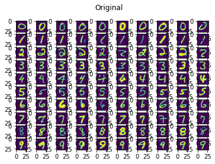

```python
indexes={i:[] for i in range(10)}

for i in range(len(test_y)):
  key=np.argmax(test_y[i])
  if len(indexes[key])<10:
    indexes[key].append(i)



fig, axes=plt.subplots(nrows=10,ncols=10)
fig.suptitle('Original')

for i in range(10):
  for j in range(10):

    axes[i,j].imshow(test_x[indexes[i][j]])
```

```python
test_x=div_frames(test_x)
```

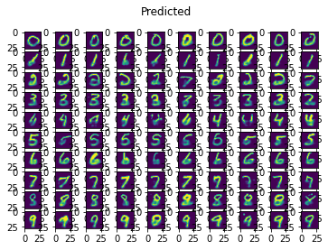

```python
evaluate(test_x,indexes)
```

The perdicted images are close to the orginial images. There are some errors - like in one image 2 is generated as 7 and also 4 is generated as 7. The corresponding images for these failures are also confusing enough.